# BONUS Missing Value Imputation

Zaremba, Dan

R markdown is a plain-text file format for integrating text and R code, and creating transparent, reproducible and interactive reports. An R markdown file (.Rmd) contains metadata, markdown and R code “chunks,”" and can be “knit” into numerous output types. Answer the test questions by adding R code to the fenced code areas below each item. There are questions that require a written answer that also need to be answered. Enter your comments in the space provided as shown below:

##### Section 1: Summarizing the data.

(1)Explore the data by summarizing it and graphing it.

```
##   BAD LOAN MORTDUE  VALUE  REASON    JOB  YOJ DEROG DELINQ     CLAGE NINQ CLNO
## 1   1 1100   25860  39025 HomeImp  Other 10.5     0      0  94.36667    1    9
## 2   1 1300   70053  68400 HomeImp  Other  7.0     0      2 121.83333    0   14
## 3   1 1500   13500  16700 HomeImp  Other  4.0     0      0 149.46667    1   10
## 4   1 1500      NA     NA                  NA    NA     NA        NA   NA   NA
## 5   0 1700   97800 112000 HomeImp Office  3.0     0      0  93.33333    0   14
## 6   1 1700   30548  40320 HomeImp  Other  9.0     0      0 101.46600    1    8
##    DEBTINC
## 1       NA
## 2       NA
## 3       NA
## 4       NA
## 5       NA
## 6 37.11361
```

```
##      BAD  LOAN MORTDUE VALUE  REASON   JOB YOJ DEROG DELINQ    CLAGE NINQ CLNO
## 5955   0 88900   48919 93371 DebtCon Other  15     0      1 205.6502    0   15
## 5956   0 88900   57264 90185 DebtCon Other  16     0      0 221.8087    0   16
## 5957   0 89000   54576 92937 DebtCon Other  16     0      0 208.6921    0   15
## 5958   0 89200   54045 92924 DebtCon Other  15     0      0 212.2797    0   15
## 5959   0 89800   50370 91861 DebtCon Other  14     0      0 213.8927    0   16
## 5960   0 89900   48811 88934 DebtCon Other  15     0      0 219.6010    0   16
##       DEBTINC
## 5955 34.81826
## 5956 36.11235
## 5957 35.85997
## 5958 35.55659
## 5959 34.34088
## 5960 34.57152
```

```
## 'data.frame':    5960 obs. of  13 variables:
##  $ BAD    : int  1 1 1 1 0 1 1 1 1 1 ...
##  $ LOAN   : int  1100 1300 1500 1500 1700 1700 1800 1800 2000 2000 ...
##  $ MORTDUE: num  25860 70053 13500 NA 97800 ...
##  $ VALUE  : num  39025 68400 16700 NA 112000 ...
##  $ REASON : Factor w/ 3 levels "","DebtCon","HomeImp": 3 3 3 1 3 3 3 3 3 3 ...
##  $ JOB    : Factor w/ 7 levels "","Mgr","Office",..: 4 4 4 1 3 4 4 4 4 6 ...
##  $ YOJ    : num  10.5 7 4 NA 3 9 5 11 3 16 ...
##  $ DEROG  : int  0 0 0 NA 0 0 3 0 0 0 ...
##  $ DELINQ : int  0 2 0 NA 0 0 2 0 2 0 ...
##  $ CLAGE  : num  94.4 121.8 149.5 NA 93.3 ...
##  $ NINQ   : int  1 0 1 NA 0 1 1 0 1 0 ...
##  $ CLNO   : int  9 14 10 NA 14 8 17 8 12 13 ...
##  $ DEBTINC: num  NA NA NA NA NA ...
```

```
##       BAD              LOAN          MORTDUE           VALUE
##  Min.   :0.0000   Min.   : 1100   Min.   :  2063   Min.   :  8000
##  1st Qu.:0.0000   1st Qu.:11100   1st Qu.: 46276   1st Qu.: 66076
##  Median :0.0000   Median :16300   Median : 65019   Median : 89236
##  Mean   :0.1995   Mean   :18608   Mean   : 73761   Mean   :101776
##  3rd Qu.:0.0000   3rd Qu.:23300   3rd Qu.: 91488   3rd Qu.:119824
##  Max.   :1.0000   Max.   :89900   Max.   :399550   Max.   :855909
##                                   NA's   :518      NA's   :112
##      REASON          JOB            YOJ             DEROG
##         : 252          : 279   Min.   : 0.000   Min.   : 0.0000
##  DebtCon:3928   Mgr    : 767   1st Qu.: 3.000   1st Qu.: 0.0000
##  HomeImp:1780   Office : 948   Median : 7.000   Median : 0.0000
##                 Other  :2388   Mean   : 8.922   Mean   : 0.2546
##                 ProfExe:1276   3rd Qu.:13.000   3rd Qu.: 0.0000
##                 Sales  : 109   Max.   :41.000   Max.   :10.0000
##                 Self   : 193   NA's   :515      NA's   :708
##      DELINQ            CLAGE             NINQ             CLNO
##  Min.   : 0.0000   Min.   :   0.0   Min.   : 0.000   Min.   : 0.0
##  1st Qu.: 0.0000   1st Qu.: 115.1   1st Qu.: 0.000   1st Qu.:15.0
##  Median : 0.0000   Median : 173.5   Median : 1.000   Median :20.0
##  Mean   : 0.4494   Mean   : 179.8   Mean   : 1.186   Mean   :21.3
##  3rd Qu.: 0.0000   3rd Qu.: 231.6   3rd Qu.: 2.000   3rd Qu.:26.0
##  Max.   :15.0000   Max.   :1168.2   Max.   :17.000   Max.   :71.0
##  NA's   :580       NA's   :308      NA's   :510      NA's   :222
##     DEBTINC
##  Min.   :  0.5245
##  1st Qu.: 29.1400
##  Median : 34.8183
##  Mean   : 33.7799
##  3rd Qu.: 39.0031
##  Max.   :203.3121
##  NA's   :1267
```

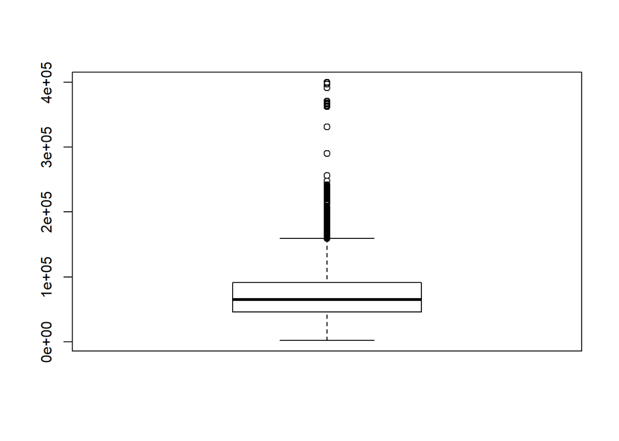

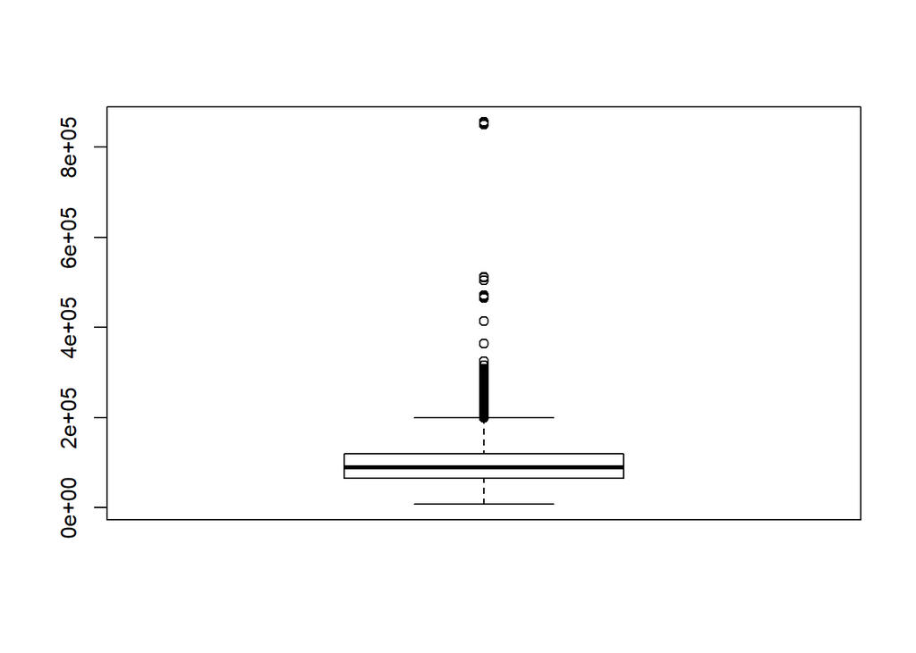

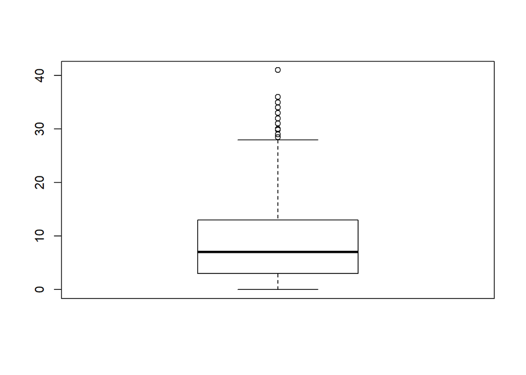

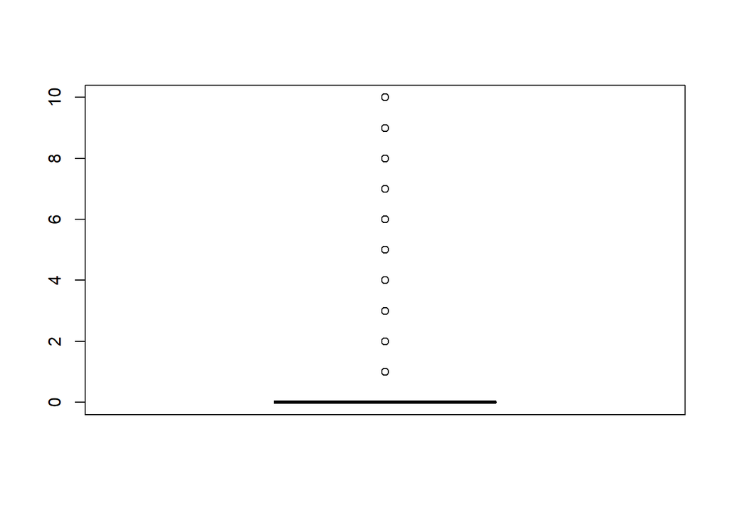

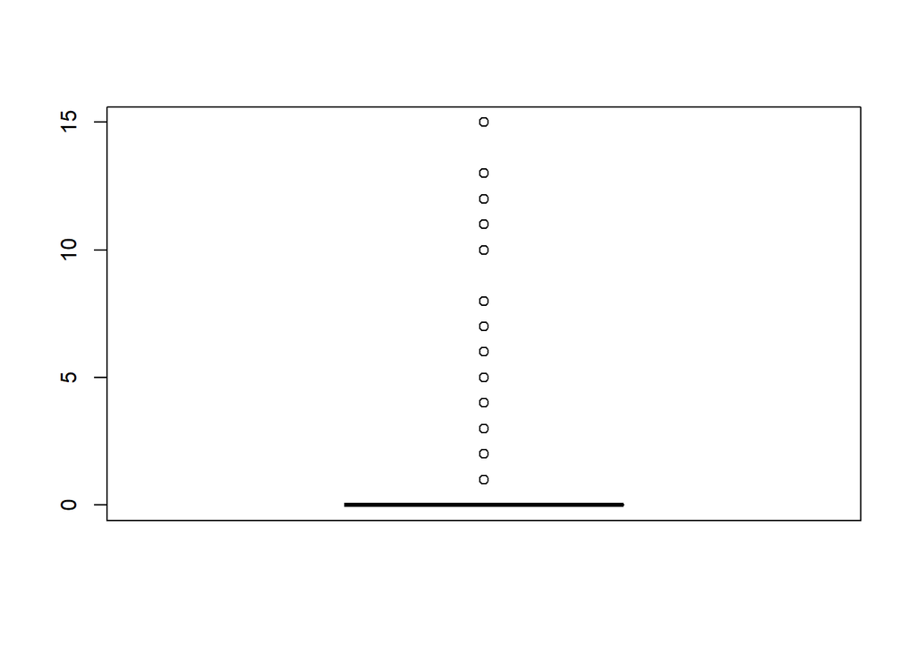

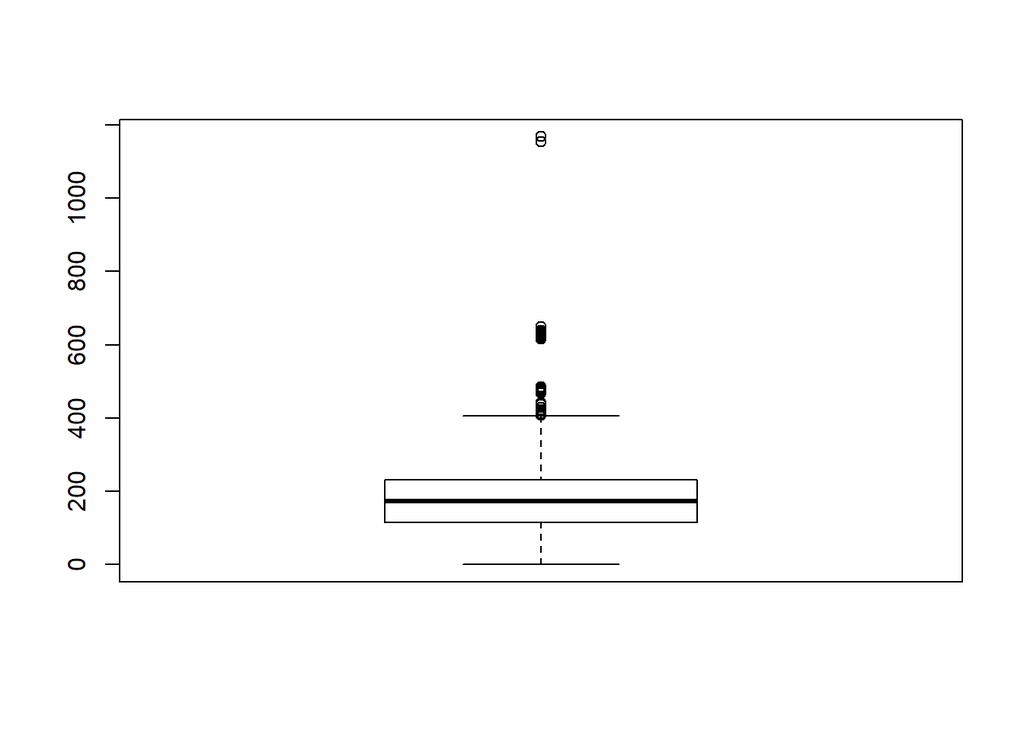